# Machine Learning: AllLife Bank Personal Loan Campaign

# **Income Education_graduate and CC_Avg are the most important variables in this model**

### Model Performance Improvement

# **Pre-pruning using grid search to improve the previous unconstrained and over-fitted model**

```python
# Choose the type of classifier.
estimator = DecisionTreeClassifier(random_state=1)

# Grid of parameters to choose from

parameters = {
    'class_weight': [None, 'balanced'],
    'max_depth': [3, 4, 5, 6, 7, 8, 9, 10],
    'min_samples_split': [10, 20, 30, 40, 50, 60, 70, 80, 90, 100],
    'min_samples_leaf': [5, 10, 15, 20, 25, 30, 35, 40, 45, 50],
    'max_leaf_nodes': [10, 15, 20, 25, 30, 35, 40, 45, 50]
}

# Type of scoring used to compare parameter combinations
acc_scorer = make_scorer(recall_score)

# Run the grid search
grid_obj = GridSearchCV(estimator, parameters, scoring=acc_scorer, cv=5)
grid_obj = grid_obj.fit(X_train, y_train)

# Set the clf to the best combination of parameters
estimator = grid_obj.best_estimator_

# Fit the best algorithm to the data.
estimator.fit(X_train, y_train)
```

```
DecisionTreeClassifier(class_weight='balanced', max_depth=3, max_leaf_nodes=10,
                       min_samples_leaf=5, min_samples_split=10,
                       random_state=1)
```

Model takes ~ 15min to run , but covers a wide range of possible parameters to find the best improvement to the first model. Good to see that 'balanced wieght' was also chosen in the best model.

I like this model for its simplicity and high recall. As mentioned prior, the most important aspect of this model is capturing ALL who may be a good fit for a personal loan which is why the model is optimizing for recall. False positives are accepted to ensure the true population of those interested in a personal loan are accounted for.

```python
decision_tree_tune_perf_train = model_performance_classification_sklearn(
    estimator, X_train, y_train
)
decision_tree_tune_perf_train
```

|  | Accuracy | Recall | Precision | F1 |
| --- | --- | --- | --- | --- |
| 0 | 0.804333 | 1.0 | 0.328375 | 0.494401 |

# **Training model shows perfect recall but awful precision. If the test results come back similar, I still believe this will be acceptable to the business.**

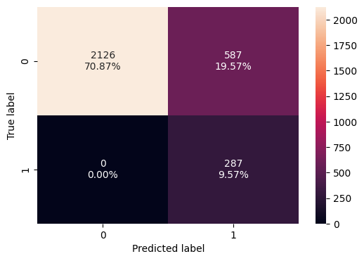

```python
confusion_matrix_sklearn(estimator, X_train, y_train)
```

```python
decision_tree_tune_perf_test = model_performance_classification_sklearn(
    estimator, X_test, y_test
)

decision_tree_tune_perf_test
```

|  | Accuracy | Recall | Precision | F1 |
| --- | --- | --- | --- | --- |
| 0 | 0.785 | 0.989637 | 0.308562 | 0.470443 |

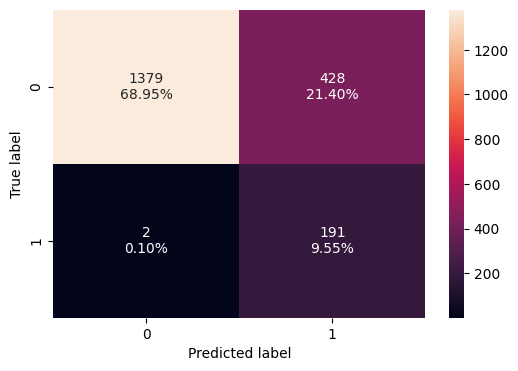

```python
confusion_matrix_sklearn(estimator, X_test, y_test)
```

# **Almost 99% recall suggesting that the model is doing a good job of capturing all who may be interested in a personal loan. However the model does have a high % of false positives which impact the precision & accuracy of the model. This is still an acceptable outcome by the business.**

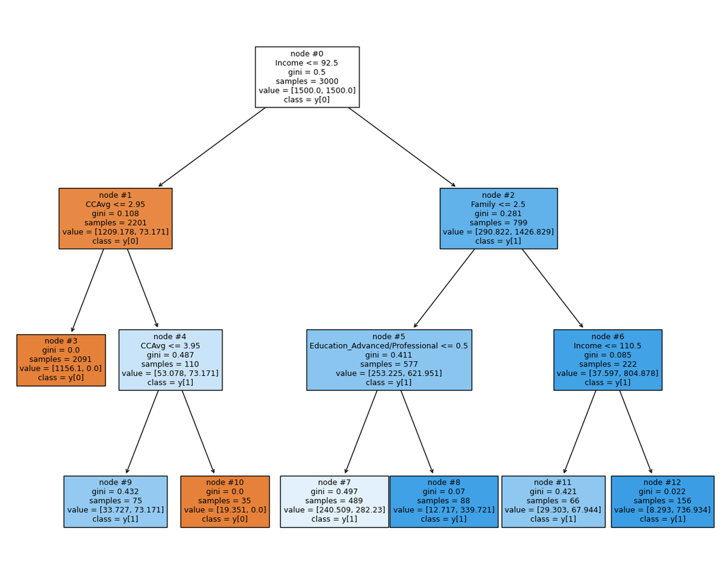

```python
plt.figure(figsize=(15, 12))

tree.plot_tree(
    estimator,
    feature_names=feature_names,
    filled=True,
    fontsize=9,
    node_ids=True,
    class_names=True,
)
plt.show()
```

# **Much simpler design of the tree b yutilizing the pre-pruning criteria**

```python
# Text report showing the rules of a decision tree -

print(tree.export_text(estimator, feature_names=feature_names, show_weights=True))
```

```
|--- Income <= 92.50
|   |--- CCAvg <= 2.95
|   |   |--- weights: [1156.10, 0.00] class: 0
|   |--- CCAvg >  2.95
|   |   |--- CCAvg <= 3.95
|   |   |   |--- weights: [33.73, 73.17] class: 1
|   |   |--- CCAvg >  3.95
|   |   |   |--- weights: [19.35, 0.00] class: 0
|--- Income >  92.50
|   |--- Family <= 2.50
|   |   |--- Education_Advanced/Professional <= 0.50
|   |   |   |--- weights: [240.51, 282.23] class: 1
|   |   |--- Education_Advanced/Professional >  0.50
|   |   |   |--- weights: [12.72, 339.72] class: 1
|   |--- Family >  2.50
|   |   |--- Income <= 110.50
|   |   |   |--- weights: [29.30, 67.94] class: 1
|   |   |--- Income >  110.50
|   |   |   |--- weights: [8.29, 736.93] class: 1
```

```python
# importance of features in the tree building ( The importance of a feature is computed as the
# (normalized) total reduction of the criterion brought by that feature. It is also known as the Gini importance )

print(
    pd.DataFrame(
        estimator.feature_importances_, columns=["Imp"], index=X_train.columns
    ).sort_values(by="Imp", ascending=False)
)
```

```
                                      Imp
Income                           0.803170
CCAvg                            0.082553
Education_Advanced/Professional  0.068054
Family                           0.046224
Age                              0.000000
ZIPCode_95                       0.000000
ZIPCode_94                       0.000000
ZIPCode_93                       0.000000
ZIPCode_92                       0.000000
ZIPCode_91                       0.000000
CreditCard                       0.000000
Education_Graduate               0.000000
Online                           0.000000
CD_Account                       0.000000
Securities_Account               0.000000
Mortgage                         0.000000
ZIPCode_96                       0.000000
```

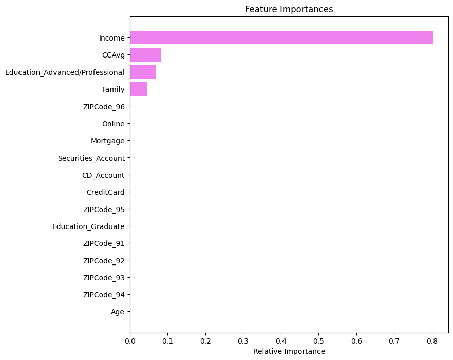

```python
importances = estimator.feature_importances_
indices = np.argsort(importances)

plt.figure(figsize=(8, 8))
plt.title("Feature Importances")
plt.barh(range(len(indices)), importances[indices], color="violet", align="center")
plt.yticks(range(len(indices)), [feature_names[i] for i in indices])
plt.xlabel("Relative Importance")
plt.show()
```

# **Number of important variables is refined down to four (Income, CCAvg, Advanced Education, and Family). Zip code, Mortgage, and CD_Account, not important to the recall of this model**

# **Cost Complexity Pruning to see if the model can be refined any more**

```python
clf = DecisionTreeClassifier(random_state=1, class_weight='balanced')
path = clf.cost_complexity_pruning_path(X_train, y_train)
ccp_alphas, impurities = path.ccp_alphas, path.impurities
```

```python
pd.DataFrame(path)
```

|  | ccp_alphas | impurities |
| --- | --- | --- |
| 0 | 0.000000e+00 | -6.714614e-17 |
| 1 | 3.683010e-19 | -6.677784e-17 |
| 2 | 1.784214e-17 | -4.893570e-17 |
| 3 | 2.123869e-17 | -2.769701e-17 |
| 4 | 3.249433e-17 | 4.797324e-18 |
| 5 | 7.485302e-17 | 7.965034e-17 |
| 6 | 1.654286e-16 | 2.450789e-16 |
| 7 | 1.780204e-04 | 3.560408e-04 |
| 8 | 1.804794e-04 | 7.169995e-04 |
| 9 | 3.219796e-04 | 1.360959e-03 |
| 10 | 3.333333e-04 | 1.694292e-03 |
| 11 | 3.463049e-04 | 2.040597e-03 |
| 12 | 3.560408e-04 | 2.396638e-03 |
| 13 | 3.606276e-04 | 3.117893e-03 |
| 14 | 4.237538e-04 | 4.812908e-03 |
| 15 | 4.321708e-04 | 6.541591e-03 |
| 16 | 5.861415e-04 | 8.300016e-03 |
| 17 | 5.919256e-04 | 9.483867e-03 |
| 18 | 6.666667e-04 | 1.015053e-02 |
| 19 | 6.666667e-04 | 1.081720e-02 |
| 20 | 7.618181e-04 | 1.234084e-02 |
| 21 | 7.847954e-04 | 1.391043e-02 |
| 22 | 8.583269e-04 | 1.476875e-02 |
| 23 | 1.003862e-03 | 1.677648e-02 |
| 24 | 1.012125e-03 | 1.778860e-02 |
| 25 | 1.030408e-03 | 2.087983e-02 |
| 26 | 1.097527e-03 | 2.526994e-02 |
| 27 | 1.712850e-03 | 2.869564e-02 |
| 28 | 2.007605e-03 | 3.271085e-02 |
| 29 | 2.606540e-03 | 3.531739e-02 |
| 30 | 2.619759e-03 | 4.055691e-02 |
| 31 | 2.998820e-03 | 4.655454e-02 |
| 32 | 3.320688e-03 | 4.987523e-02 |
| 33 | 5.118001e-03 | 5.499323e-02 |
| 34 | 5.860326e-03 | 6.671389e-02 |
| 35 | 2.548864e-02 | 9.220252e-02 |
| 36 | 3.828303e-02 | 2.070516e-01 |
| 37 | 2.929484e-01 | 5.000000e-01 |

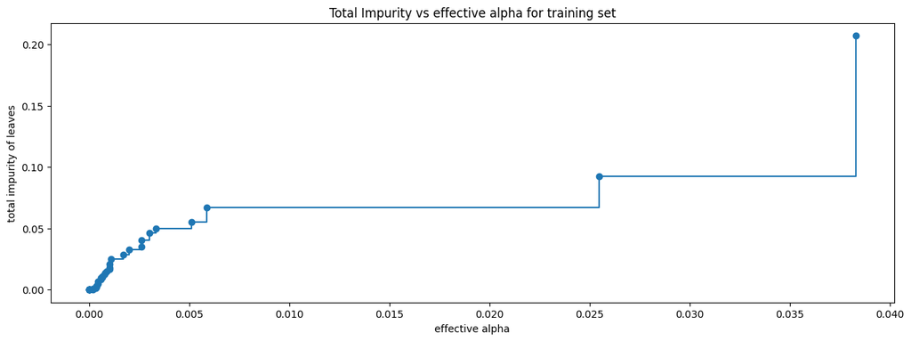

```python
fig, ax = plt.subplots(figsize=(15, 5))
ax.plot(ccp_alphas[:-1], impurities[:-1], marker="o", drawstyle="steps-post")
ax.set_xlabel("effective alpha")
ax.set_ylabel("total impurity of leaves")
ax.set_title("Total Impurity vs effective alpha for training set")
plt.show()
```

```python
clfs = []
for ccp_alpha in ccp_alphas:
    clf = DecisionTreeClassifier(random_state=1, ccp_alpha=ccp_alpha)
    clf.fit(X_train, y_train)
    clfs.append(clf)
print(
    "Number of nodes in the last tree is: {} with ccp_alpha: {}".format(
        clfs[-1].tree_.node_count, ccp_alphas[-1]
    )
)
```

```
Number of nodes in the last tree is: 1 with ccp_alpha: 0.29294838285268826
```

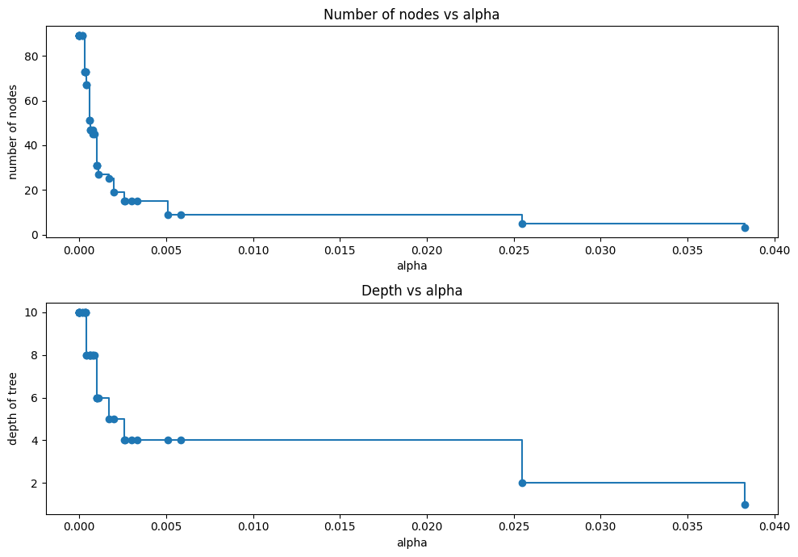

```python
clfs = clfs[:-1]
ccp_alphas = ccp_alphas[:-1]

node_counts = [clf.tree_.node_count for clf in clfs]
depth = [clf.tree_.max_depth for clf in clfs]
fig, ax = plt.subplots(2, 1, figsize=(10, 7))
ax[0].plot(ccp_alphas, node_counts, marker="o", drawstyle="steps-post")
ax[0].set_xlabel("alpha")
ax[0].set_ylabel("number of nodes")
ax[0].set_title("Number of nodes vs alpha")
ax[1].plot(ccp_alphas, depth, marker="o", drawstyle="steps-post")
ax[1].set_xlabel("alpha")
ax[1].set_ylabel("depth of tree")
ax[1].set_title("Depth vs alpha")
fig.tight_layout()
```

```python
recall_train = []
for clf in clfs:
    pred_train = clf.predict(X_train)
    values_train = recall_score(y_train, pred_train)
    recall_train.append(values_train)
```

```python
recall_test = []
for clf in clfs:
    pred_test = clf.predict(X_test)
    values_test = recall_score(y_test, pred_test)
    recall_test.append(values_test)
```

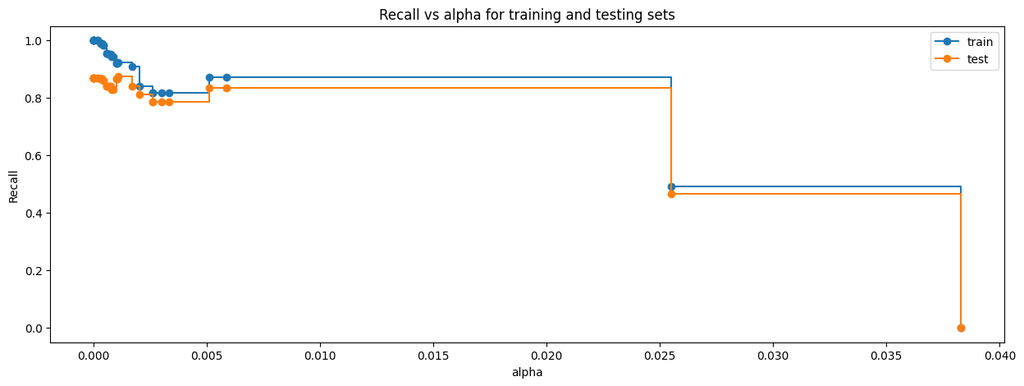

```python
fig, ax = plt.subplots(figsize=(15, 5))
ax.set_xlabel("alpha")
ax.set_ylabel("Recall")
ax.set_title("Recall vs alpha for training and testing sets")
ax.plot(ccp_alphas, recall_train, marker="o", label="train", drawstyle="steps-post")
ax.plot(ccp_alphas, recall_test, marker="o", label="test", drawstyle="steps-post")
ax.legend()
plt.show()
```

```python
# creating the model where we get highest train and test recall
index_best_model = np.argmax(recall_test)
best_model = clfs[index_best_model]
print(best_model)
```

```
DecisionTreeClassifier(ccp_alpha=0.0010975272432859422, random_state=1)
```

```python
decision_tree_postpruned_perf_train = model_performance_classification_sklearn(
    best_model, X_train, y_train
)
decision_tree_postpruned_perf_train
```

|  | Accuracy | Recall | Precision | F1 |
| --- | --- | --- | --- | --- |
| 0 | 0.989333 | 0.923345 | 0.963636 | 0.94306 |

# **Recall is training lower in the post-pruning model than the pre-pruning model**

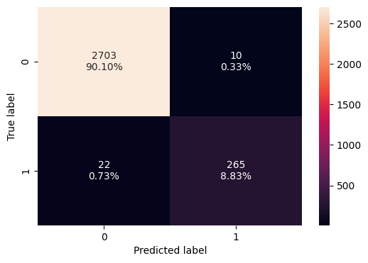

```python
confusion_matrix_sklearn(best_model, X_train, y_train)
```

```python
decision_tree_postpruned_perf_test = model_performance_classification_sklearn(
    best_model, X_test, y_test
)
decision_tree_postpruned_perf_test
```

|  | Accuracy | Recall | Precision | F1 |
| --- | --- | --- | --- | --- |
| 0 | 0.9825 | 0.875648 | 0.938889 | 0.906166 |

# **Test model also showing poor recall vs train and vs pre-pruning model**

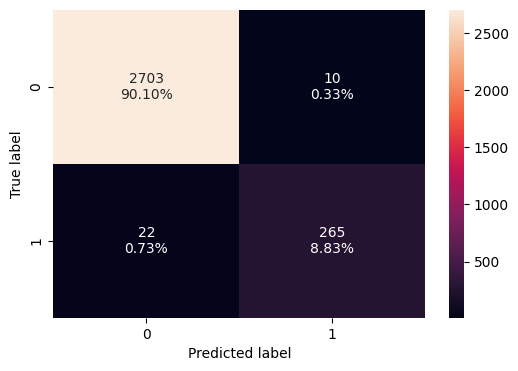

```python
confusion_matrix_sklearn(best_model, X_train, y_train)
```

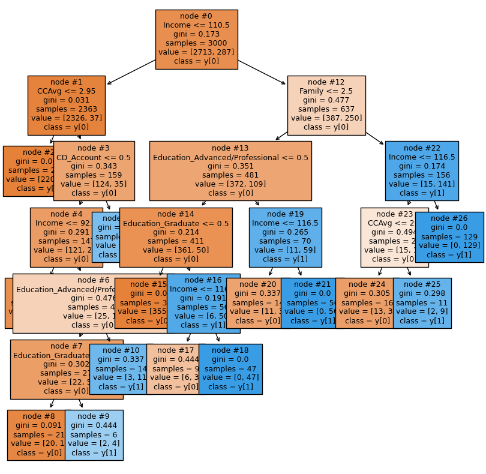

```python
plt.figure(figsize=(10, 10))

out = tree.plot_tree(
    best_model,
    feature_names=feature_names,
    filled=True,
    fontsize=9,
    node_ids=True,
    class_names=True,
)
for o in out:
    arrow = o.arrow_patch
    if arrow is not None:
        arrow.set_edgecolor("black")
        arrow.set_linewidth(1)
plt.show()
plt.show()
```

```python
print(tree.export_text(best_model, feature_names=feature_names, show_weights=True))
```

```
|--- Income <= 110.50
|   |--- CCAvg <= 2.95
|   |   |--- weights: [2202.00, 2.00] class: 0
|   |--- CCAvg >  2.95
|   |   |--- CD_Account <= 0.50
|   |   |   |--- Income <= 92.50
|   |   |   |   |--- weights: [96.00, 10.00] class: 0
|   |   |   |--- Income >  92.50
|   |   |   |   |--- Education_Advanced/Professional <= 0.50
|   |   |   |   |   |--- Education_Graduate <= 0.50
|   |   |   |   |   |   |--- weights: [20.00, 1.00] class: 0
|   |   |   |   |   |--- Education_Graduate >  0.50
|   |   |   |   |   |   |--- weights: [2.00, 4.00] class: 1
|   |   |   |   |--- Education_Advanced/Professional >  0.50
|   |   |   |   |   |--- weights: [3.00, 11.00] class: 1
|   |   |--- CD_Account >  0.50
|   |   |   |--- weights: [3.00, 9.00] class: 1
|--- Income >  110.50
|   |--- Family <= 2.50
|   |   |--- Education_Advanced/Professional <= 0.50
|   |   |   |--- Education_Graduate <= 0.50
|   |   |   |   |--- weights: [355.00, 0.00] class: 0
|   |   |   |--- Education_Graduate >  0.50
|   |   |   |   |--- Income <= 116.50
|   |   |   |   |   |--- weights: [6.00, 3.00] class: 0
|   |   |   |   |--- Income >  116.50
|   |   |   |   |   |--- weights: [0.00, 47.00] class: 1
|   |   |--- Education_Advanced/Professional >  0.50
|   |   |   |--- Income <= 116.50
|   |   |   |   |--- weights: [11.00, 3.00] class: 0
|   |   |   |--- Income >  116.50
|   |   |   |   |--- weights: [0.00, 56.00] class: 1
|   |--- Family >  2.50
|   |   |--- Income <= 116.50
|   |   |   |--- CCAvg <= 2.70
|   |   |   |   |--- weights: [13.00, 3.00] class: 0
|   |   |   |--- CCAvg >  2.70
|   |   |   |   |--- weights: [2.00, 9.00] class: 1
|   |   |--- Income >  116.50
|   |   |   |--- weights: [0.00, 129.00] class: 1
```

```python
print(
    pd.DataFrame(
        best_model.feature_importances_, columns=["Imp"], index=X_train.columns
    ).sort_values(by="Imp", ascending=False)
)
```

```
                                      Imp
Income                           0.390240
Family                           0.231710
Education_Graduate               0.173047
Education_Advanced/Professional  0.147687
CCAvg                            0.041686
CD_Account                       0.015629
Age                              0.000000
ZIPCode_92                       0.000000
ZIPCode_95                       0.000000
ZIPCode_94                       0.000000
ZIPCode_93                       0.000000
CreditCard                       0.000000
ZIPCode_91                       0.000000
Online                           0.000000
Securities_Account               0.000000
Mortgage                         0.000000
ZIPCode_96                       0.000000
```

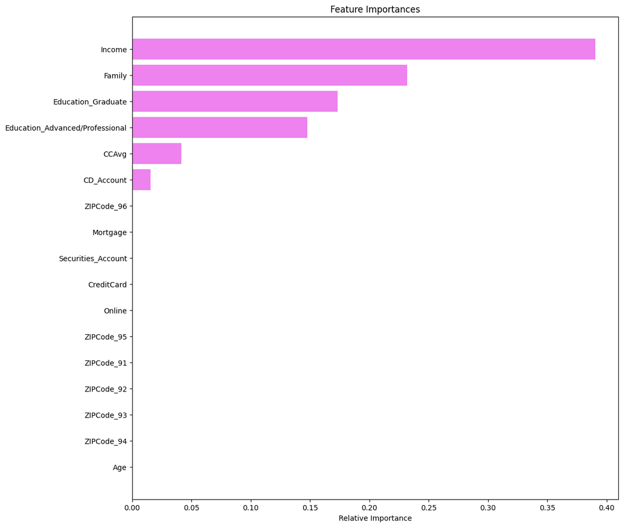

```python
importances = best_model.feature_importances_
indices = np.argsort(importances)

plt.figure(figsize=(12, 12))
plt.title("Feature Importances")
plt.barh(range(len(indices)), importances[indices], color="violet", align="center")
plt.yticks(range(len(indices)), [feature_names[i] for i in indices])
plt.xlabel("Relative Importance")
plt.show()
```

## **Number of important features increases to six compared to the four in the pre-pruned model**

## Model Comparison and Final Model Selection

```python
# training performance comparison

models_train_comp_df = pd.concat(
    [
        decision_tree_perf_train.T,
        decision_tree_tune_perf_train.T,
        decision_tree_postpruned_perf_train.T,
    ],
    axis=1,
)
models_train_comp_df.columns = [
    "Decision Tree sklearn",
    "Decision Tree (Pre-Pruning)",
    "Decision Tree (Post-Pruning)",
]
print("Training performance comparison:")
models_train_comp_df
```

```
Training performance comparison:
```

|  | Decision Tree sklearn | Decision Tree (Pre-Pruning) | Decision Tree (Post-Pruning) |
| --- | --- | --- | --- |
| Accuracy | 1.0 | 0.804333 | 0.989333 |
| Recall | 1.0 | 1.000000 | 0.923345 |
| Precision | 1.0 | 0.328375 | 0.963636 |
| F1 | 1.0 | 0.494401 | 0.943060 |

```python
# test performance comparison

models_train_comp_df = pd.concat(
    [
        decision_tree_perf_test.T,
        decision_tree_tune_perf_test.T,
        decision_tree_postpruned_perf_test.T,
    ],
    axis=1,
)
models_train_comp_df.columns = [
    "Decision Tree sklearn",
    "Decision Tree (Pre-Pruning)",
    "Decision Tree (Post-Pruning)",
]
print("Test set performance comparison:")
models_train_comp_df
```

```
Test set performance comparison:
```

|  | Decision Tree sklearn | Decision Tree (Pre-Pruning) | Decision Tree (Post-Pruning) |
| --- | --- | --- | --- |
| Accuracy | 0.977500 | 0.785000 | 0.982500 |
| Recall | 0.849741 | 0.989637 | 0.875648 |
| Precision | 0.911111 | 0.308562 | 0.938889 |
| F1 | 0.879357 | 0.470443 | 0.906166 |

# **The grid search pre-pruned model is the best model showing 100% recall in train and nearly 99% recall in test. While this model has a lower accuracy and precision scores vs the other models, the maximizing recall criteria makes the grid search model the best for implementation**

## Actionable Insights and Business Recommendations

- What recommedations would you suggest to the bank?

```python
!jupyter nbconvert --to html '/content/drive/MyDrive/colabnotebooks/personal_loan/AIML_ML_Project_full_code_notebooke_DavidBingham.ipynb' --output '/content/drive/MyDrive/colabnotebooks/personal_loan/PersonalLoan_FullCode_DavidBingham.html'
```

[output not shown]

[output cut: 133 more lines]

[output not shown]